# FOMC Belief Networks: Extensions and Robustness Checks

Follow-up to the DAT 301 Project 1 report

Bhavana Kannan

November 2026

# 1 Purpose

The submitted report (`track2_report.Rmd`, tag `v1.0-submitted`) found that the minimum spanning tree (MST) of Kalshi FOMC meetings looked different after the 2026-09-16 hike: 2 of 6 edges shared, correlations about twice as strong, and a 41-day check suggesting the change was not a short-window artifact. This document re-runs that analysis with the refactored functions in `R/wrangle.R` and `R/graph.R` and adds checks the report did not have time for:

1. a fix for a daylight-saving-time bug in the trading-date step;
2. an exact permutation test in place of the Monte Carlo one;
3. a null distribution for “two 41-day samples from the same regime”, built from every 41-day block of the before window;
4. tests of whether correlations got stronger, calibrated the same way;
5. bootstrap edge stability;
6. rolling-window trees;
7. robustness to the correlation measure, stale-quote handling, leg coding and cleaning thresholds.

The short version: the refactor reproduces the report exactly, the DST fix does not change the trees, and **the after-hike network is not distinguishable from what a 41-day window of the before period produces.** The contrast in the report comes mostly from a steady rise in Kalshi liquidity through 2026, not from the hike.

```r
raw <- read_raw("../data/raw", "../data/meetings.csv")
main   <- build_panel(raw, date_rule = "est")
report <- build_panel(raw, date_rule = "eastern")
split_windows <- function(b) list(before = dplyr::filter(b$changes, window == "before"),
                                  after  = dplyr::filter(b$changes, window == "after"))
w  <- split_windows(main)
Cb <- cor_matrix(w$before, NODES); Ca <- cor_matrix(w$after, NODES)
tb <- build_mst(Cb);               ta <- build_mst(Ca)
```

# 2 Daylight-saving-time fix

Kalshi’s daily candles end at midnight US Eastern *Standard* Time (05:00 UTC) in winter and at 04:00 UTC in summer. The report converted `ts - 1 s` to an America/New_York date. In the original pull, the candle for Sunday 2026-03-08 was stamped 05:00 UTC on 2026-03-09, which is already 01:00 daylight time, so it landed on 2026-03-09. Five meetings then had two rows on 03-09 and none on 03-08; their leg prices summed to about 2 and the day was dropped by the 0.80 to 1.20 filter. `add_trading_date(rule = "est")` reads the timestamp on a fixed UTC-5 clock instead, which puts both 04:00 and 05:00 UTC candle ends on the previous day.

```r
wr <- split_windows(report)
Cb_r <- cor_matrix(wr$before, NODES); Ca_r <- cor_matrix(wr$after, NODES)
dup_rows <- raw$candles |> add_trading_date("eastern") |> dplyr::count(market, date) |> dplyr::filter(n > 1)
tibble(
  quantity = c("leg-days stamped twice", "meeting-days kept", "meeting-days dropped (sum outside 0.80-1.20)",
               "largest change in a before-window correlation", "largest change in an after-window correlation",
               "before-tree edges unchanged (of 6)", "after-tree edges unchanged (of 6)"),
  report_rule = c(nrow(dup_rows), nrow(report$panel), nrow(report$dropped), "", "", "", ""),
  fixed_rule  = c(nrow(raw$candles |> add_trading_date("est") |> dplyr::count(market, date) |> dplyr::filter(n > 1)),
                  nrow(main$panel), nrow(main$dropped),
                  sprintf("%.3f", max(abs(Cb - Cb_r))), sprintf("%.3f", max(abs(Ca - Ca_r))),
                  n_shared(tb, build_mst(Cb_r)), n_shared(ta, build_mst(Ca_r)))
) |> knitr::kable(col.names = c("", "Report (America/New_York)", "Fixed (UTC-5)"), align = "lrr")
```

|  | Report (America/New_York) | Fixed (UTC-5) |
| --- | --- | --- |
| leg-days stamped twice | 25 | 0 |
| meeting-days kept | 2939 | 2944 |
| meeting-days dropped (sum outside 0.80-1.20) | 123 | 118 |
| largest change in a before-window correlation |  | 0.073 |
| largest change in an after-window correlation |  | 0.000 |
| before-tree edges unchanged (of 6) |  | 6 |
| after-tree edges unchanged (of 6) |  | 6 |

The fix recovers 5 meeting-days and moves one before-window correlation by up to 0.073, but both trees are identical. A fresh download on 2026-11-14 also showed that Kalshi now stamps that candle at 04:00 UTC, so a re-pull and the original pull disagree on these timestamps; the UTC-5 rule gives the same dates for both.

# 3 Exact permutation test

With 7 meetings there are only 7! = 5,040 ways to relabel the after tree, so the p-value can be computed exactly instead of estimated from 5,000 random draws.

```r
mc <- perm_shared_mc(tb, ta, NODES, n_perm = 5000, seed = 301)
ex <- perm_shared_exact(tb, ta, NODES)
tibble(test = c("Monte Carlo, 5000 draws (report)", "Exact, all 5040 relabellings"),
       shared_edges = c(mc$observed, ex$observed),
       mean_by_chance = c(mean(mc$null), mean(ex$null)),
       p_value = c(mc$p, ex$p)) |> knitr::kable(digits = 3)
```

| test | shared_edges | mean_by_chance | p_value |
| --- | --- | --- | --- |
| Monte Carlo, 5000 draws (report) | 2 | 1.686 | 0.554 |
| Exact, all 5040 relabellings | 2 | 1.714 | 0.563 |

The exact p-value is 0.563, the same conclusion as the report’s 0.554: 2 shared edges is about what random labels give. The exact test is used for every comparison below.

# 4 Is sharing only 2 edges unusual?

The permutation test asks whether the two trees agree *more* than random trees. The report’s question was the reverse: did the network *change*? To answer that, we need to know how much two trees from the *same* regime normally agree when one is built from only 41 days. The report built one such tree (the last 41 days before the hike), which shared 5 of 6 edges with the full before tree. Here every contiguous 41-day block of the before window is used.

For each block, two comparisons are made: the block’s tree against the tree of the *rest* of the before window (two disjoint samples, the same setup as after vs before), and against the tree of the *whole* before window (the report’s in-sample comparison).

```r
bn <- block_null(w$before, NODES, block_len = 41)
liquid_start <- as.Date("2026-04-01")   # from April 2026 at most a third of before-window days are unchanged
bn_liquid <- dplyr::filter(bn, start >= liquid_start)
obs_shared <- n_shared(tb, ta)
tibble(null = c("all 41-day blocks, block vs rest", "liquid blocks (from 2026-04), block vs rest",
                "all 41-day blocks, block vs whole window (report's check)"),
       blocks = c(nrow(bn), nrow(bn_liquid), nrow(bn)),
       mean_shared = c(mean(bn$shared_rest), mean(bn_liquid$shared_rest), mean(bn$shared_full)),
       share_with_2_or_fewer = c(mean(bn$shared_rest <= obs_shared), mean(bn_liquid$shared_rest <= obs_shared),
                                 mean(bn$shared_full <= obs_shared)),
       share_with_5_or_more = c(mean(bn$shared_rest >= 5), mean(bn_liquid$shared_rest >= 5), mean(bn$shared_full >= 5))) |>
  knitr::kable(digits = 2)
```

| null | blocks | mean_shared | share_with_2_or_fewer | share_with_5_or_more |
| --- | --- | --- | --- | --- |
| all 41-day blocks, block vs rest | 304 | 1.51 | 0.89 | 0.00 |
| liquid blocks (from 2026-04), block vs rest | 128 | 1.16 | 0.97 | 0.00 |
| all 41-day blocks, block vs whole window (report’s check) | 304 | 2.24 | 0.69 | 0.01 |

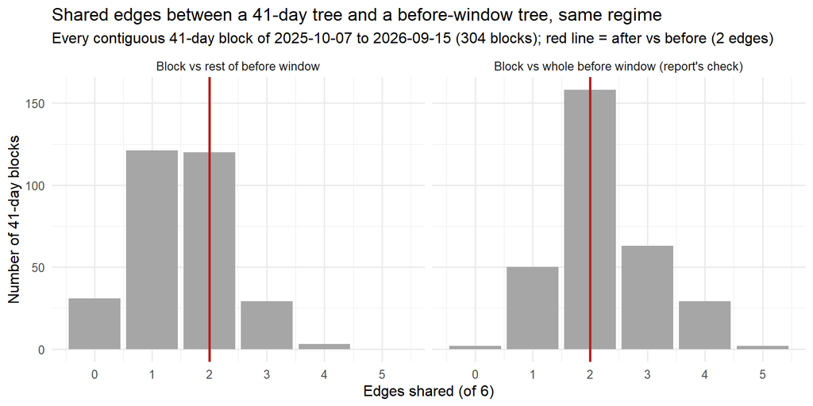

```r
dplyr::bind_rows(
  dplyr::transmute(bn, comparison = "Block vs rest of before window", shared = shared_rest),
  dplyr::transmute(bn, comparison = "Block vs whole before window (report's check)", shared = shared_full)
) |>
  ggplot(aes(x = shared)) +
  geom_bar(fill = "grey65") +
  geom_vline(xintercept = obs_shared, colour = "firebrick", linewidth = 1) +
  facet_wrap(~ comparison) +
  scale_x_continuous(breaks = 0:6) +
  labs(title = "Shared edges between a 41-day tree and a before-window tree, same regime",
       subtitle = sprintf("Every contiguous 41-day block of 2025-10-07 to 2026-09-15 (%d blocks); red line = after vs before (%d edges)",
                          nrow(bn), obs_shared),
       x = "Edges shared (of 6)", y = "Number of 41-day blocks")
```

**What to notice.** Two samples from the *same* before period usually share only 1 or 2 edges: 89% of blocks share 2 or fewer with the rest of the window, and 97% do in the liquid period alone. The after tree’s 2 shared edges are therefore exactly what no change at all would produce. The report’s 41-day check (5 of 6) was the exception: only 2 of 304 blocks reach 5 even in the easier in-sample comparison. **Why it matters:** with 7 nodes and 41 days, a tree is too noisy for its shape to show a change in regime. The report’s conclusion that “the old structure did not carry over” does not survive this check.

# 5 Did the links get stronger?

The report noted that correlations roughly doubled after the hike (mean |rho| 0.13 before, 0.27 after). The same block null shows whether a 41-day window with mean |rho| 0.27 is unusual for the before regime. The Mantel correlation (agreement between two distance matrices) is checked the same way.

```r
mantel_after <- mantel_exact(to_distance(Cb), to_distance(Ca))
tibble(statistic = c("mean |rho|", "Mantel r with the before matrix"),
       after_window = c(mean_abs_rho(Ca), mantel_after$r),
       before_blocks_median = c(median(bn$mean_abs_rho), median(bn$mantel_r, na.rm = TRUE)),
       share_of_blocks_as_extreme = c(mean(bn$mean_abs_rho >= mean_abs_rho(Ca)),
                                      mean(bn$mantel_r <= mantel_after$r, na.rm = TRUE)),
       share_of_liquid_blocks_as_extreme = c(mean(bn_liquid$mean_abs_rho >= mean_abs_rho(Ca)),
                                             mean(bn_liquid$mantel_r <= mantel_after$r, na.rm = TRUE))) |>
  knitr::kable(digits = 2)
```

| statistic | after_window | before_blocks_median | share_of_blocks_as_extreme | share_of_liquid_blocks_as_extreme |
| --- | --- | --- | --- | --- |
| mean \|rho\| | 0.27 | 0.30 | 0.56 | 0.54 |
| Mantel r with the before matrix | -0.12 | -0.15 | 0.55 | 0.45 |

An after window with links this strong is ordinary: 56% of 41-day blocks before the hike have links at least as strong. The full before window averages lower because it mixes months of stale quotes with months of active trading.

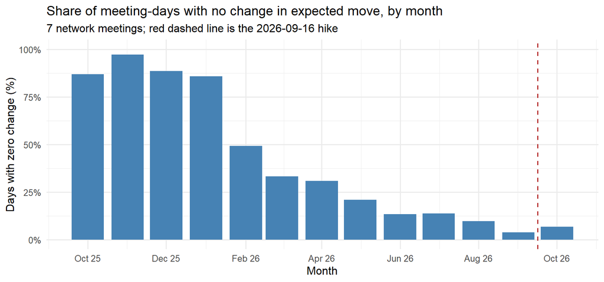

```r
stale <- main$changes |>
  tidyr::pivot_longer(dplyr::all_of(NODES), names_to = "meeting", values_to = "change") |>
  dplyr::filter(!is.na(change)) |>
  dplyr::mutate(month = lubridate::floor_date(date, "month")) |>
  dplyr::group_by(month) |>
  dplyr::summarise(zero_share = mean(change == 0), .groups = "drop")
ggplot(stale, aes(x = month, y = zero_share)) +
  geom_col(fill = "steelblue") +
  geom_vline(xintercept = HIKE_DATE, linetype = "dashed", colour = "firebrick") +
  scale_y_continuous(labels = scales::percent, limits = c(0, 1)) +
  scale_x_date(date_breaks = "2 months", date_labels = "%b %y") +
  labs(title = "Share of meeting-days with no change in expected move, by month",
       subtitle = "7 network meetings; red dashed line is the 2026-09-16 hike",
       x = "Month", y = "Days with zero change (%)")
```

**What to notice.** Stale quoting fades steadily through 2026 and is already near its after-hike level in August and September, *before* the hike. The drop in unchanged days that the report linked to the hike is a trend in Kalshi liquidity that started months earlier.

**A test that does not work here.** The Jennrich (1970) chi-square test of equal correlation matrices gives p = 1.6e-07 for before vs after. But it assumes independent, normally distributed days, and daily changes here are heavy-tailed, mostly zero early on, and drift over time. Applied to 41-day blocks against the rest of the before window, it rejects almost always:

```r
jp <- sapply(seq(1, nrow(w$before) - 40, by = 5), function(s) {
  idx <- s:(s + 40)
  C1 <- cor_matrix(w$before[idx, ], NODES); C2 <- cor_matrix(w$before[-idx, ], NODES)
  if (anyNA(C1)) return(NA_real_)
  jennrich_test(C1, 41, C2, nrow(w$before) - 41)$p
})
c(blocks_tested = sum(!is.na(jp)), share_rejected_at_0.05 = mean(jp < 0.05, na.rm = TRUE))
```

```
##          blocks_tested share_rejected_at_0.05
##                     54                      1
```

A test that rejects “same matrix” for two halves of the same period carries no information, so its before-vs-after p-value is not evidence of a change. The block null above is the calibrated comparison.

# 6 Edge stability

How sure are we of each tree’s edges? A moving-block bootstrap (blocks of 5 days, to keep short-run dependence) resamples each window 1,000 times and rebuilds the tree.

```r
bs <- dplyr::bind_rows(
  dplyr::mutate(block_bootstrap_edges(w$before, NODES, n_boot = 1000, block_len = 5), window = "Before hike"),
  dplyr::mutate(block_bootstrap_edges(w$after,  NODES, n_boot = 1000, block_len = 5), window = "After hike")
) |>
  dplyr::mutate(in_tree = ifelse(window == "Before hike", edge %in% edge_keys(tb), edge %in% edge_keys(ta)),
                window = factor(window, levels = c("Before hike", "After hike")))
```

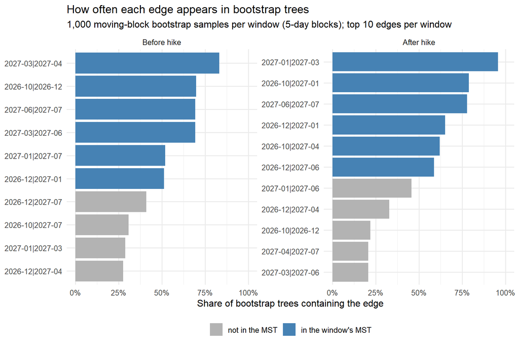

```r
bs |>
  dplyr::group_by(window) |> dplyr::slice_max(freq, n = 10) |> dplyr::ungroup() |>
  ggplot(aes(x = freq, y = reorder(interaction(edge, window, sep = "~"), freq), fill = in_tree)) +
  geom_col() +
  facet_wrap(~ window, scales = "free_y") +
  scale_y_discrete(labels = function(x) sub("~.*", "", x)) +   # sort bars within each panel, show only the edge
  scale_fill_manual(values = c(`TRUE` = "steelblue", `FALSE` = "grey70"),
                    labels = c(`TRUE` = "in the window's MST", `FALSE` = "not in the MST")) +
  scale_x_continuous(labels = scales::percent, limits = c(0, 1)) +
  labs(title = "How often each edge appears in bootstrap trees",
       subtitle = "1,000 moving-block bootstrap samples per window (5-day blocks); top 10 edges per window",
       x = "Share of bootstrap trees containing the edge", y = NULL, fill = NULL) +
  theme(legend.position = "bottom")
```

**What to notice.** Only one edge per window is in at least 80% of bootstrap trees: 2027-03|2027-04 before the hike and 2027-01|2027-03 after it. The other tree edges appear in 51% to 79% of resamples, so any single tree is one draw from a wide range of plausible trees. This is consistent with the block-null result.

# 7 Rolling-window trees

A tree on a 60-day rolling window shows how the network moves over time instead of in two blocks.

```r
rt <- rolling_trees(main$changes |> dplyr::filter(!is.na(window)), NODES, width = 60,
                    ref_trees = list(before = tb, after = ta))
```

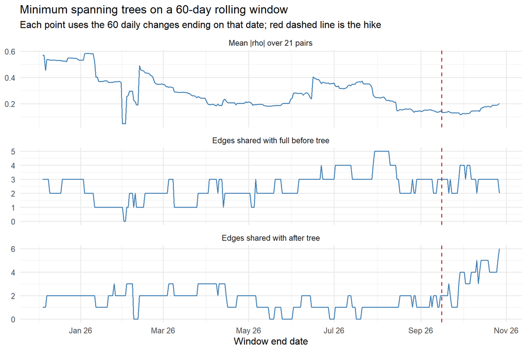

```r
rt |>
  tidyr::pivot_longer(c(mean_abs_rho, shared_before, shared_after), names_to = "series", values_to = "value") |>
  dplyr::mutate(series = factor(series, levels = c("mean_abs_rho", "shared_before", "shared_after"),
                                labels = c("Mean |rho| over 21 pairs", "Edges shared with full before tree",
                                           "Edges shared with after tree"))) |>
  ggplot(aes(x = end_date, y = value)) +
  geom_line(colour = "steelblue") +
  geom_vline(xintercept = HIKE_DATE, linetype = "dashed", colour = "firebrick") +
  facet_wrap(~ series, ncol = 1, scales = "free_y") +
  scale_x_date(date_breaks = "2 months", date_labels = "%b %y") +
  labs(title = "Minimum spanning trees on a 60-day rolling window",
       subtitle = "Each point uses the 60 daily changes ending on that date; red dashed line is the hike",
       x = "Window end date", y = NULL)
```

# 8 Robustness of the before and after trees

Each variant changes one choice and rebuilds both trees. “Same as main” counts edges in common with the main trees.

```r
variant <- function(label, b = main, method = "pearson", both_moved = FALSE) {
  ww <- split_windows(b)
  C1 <- cor_matrix(ww$before, NODES, method, both_moved); C2 <- cor_matrix(ww$after, NODES, method, both_moved)
  t1 <- build_mst(C1); t2 <- build_mst(C2)
  tibble(variant = label, shared_before_after = n_shared(t1, t2), exact_p = perm_shared_exact(t1, t2, NODES)$p,
         mean_abs_rho_before = mean_abs_rho(C1), mean_abs_rho_after = mean_abs_rho(C2),
         before_same_as_main = n_shared(t1, tb), after_same_as_main = n_shared(t2, ta))
}
m75 <- c(CUT50P = -75, CUT25 = -25, HOLD = 0, HIKE25 = 25, HIKE50P = 75)
rob <- dplyr::bind_rows(
  variant("main (Pearson, fixed dates)"),
  variant("report date rule", report),
  variant("Spearman correlation", method = "spearman"),
  variant("Pearson, only days both meetings moved", both_moved = TRUE),
  variant("Spearman, only days both meetings moved", method = "spearman", both_moved = TRUE),
  variant("'more than 25 bp' legs coded +/-75 bp", build_panel(raw, move_bp = m75)),
  variant("spread filter 10 cents", build_panel(raw, max_spread = 0.10)),
  variant("spread filter 30 cents", build_panel(raw, max_spread = 0.30)),
  variant("forward-fill at most 2 days", build_panel(raw, max_stale = 2)),
  variant("forward-fill at most 10 days", build_panel(raw, max_stale = 10))
)
knitr::kable(rob, digits = 2, col.names = c("Variant", "Shared (of 6)", "Exact p", "Mean |rho| before",
                                              "Mean |rho| after", "Before tree same as main", "After tree same as main"))
```

| Variant | Shared (of 6) | Exact p | Mean \|rho\| before | Mean \|rho\| after | Before tree same as main | After tree same as main |
| --- | --- | --- | --- | --- | --- | --- |
| main (Pearson, fixed dates) | 2 | 0.56 | 0.13 | 0.27 | 6 | 6 |
| report date rule | 2 | 0.56 | 0.12 | 0.27 | 6 | 6 |
| Spearman correlation | 3 | 0.19 | 0.07 | 0.22 | 4 | 5 |
| Pearson, only days both meetings moved | 2 | 0.56 | 0.14 | 0.27 | 6 | 6 |
| Spearman, only days both meetings moved | 2 | 0.58 | 0.09 | 0.24 | 4 | 4 |
| ‘more than 25 bp’ legs coded +/-75 bp | 0 | 1.00 | 0.11 | 0.25 | 5 | 4 |
| spread filter 10 cents | 0 | 1.00 | 0.11 | 0.20 | 4 | 2 |
| spread filter 30 cents | 2 | 0.57 | 0.16 | 0.27 | 3 | 4 |
| forward-fill at most 2 days | 1 | 0.92 | 0.14 | 0.29 | 5 | 5 |
| forward-fill at most 10 days | 1 | 0.89 | 0.15 | 0.28 | 3 | 6 |

**What to notice.** No variant finds more before-after agreement than chance would give (every exact p-value is 0.19 or higher), so the “trees share little” result is stable, but by the block-null result above it is also what no change would produce. Dropping zero-change days leaves both Pearson trees exactly as they were. Every other choice moves edges: the spread filter, the forward-fill limit, the correlation measure and the coding of the “more than 25 bp” legs each change 1 to 4 of the 6 edges in at least one tree. The tree shapes depend on cleaning choices about as much as on the data, which is another reason not to read much into a difference between two single trees. Mean |rho| roughly doubles from before to after in every variant; the block null shows that this comes from the long before window being diluted by stale months.

# 9 What changes in the conclusions

- **Question 1 (which meetings are linked) stands, with a caveat.** Before the hike, the tree is a chain that mostly links meetings close in time, and its most stable edge (2027-03|2027-04) appears in over 80% of bootstrap trees. The rest of the chain is uncertain.
- **Question 2 (did the network change after the hike) has no detectable answer with this data.** A 41-day window after the hike looks like a typical 41-day window from before it, in tree shape, link strength, and Mantel agreement. The report’s “yes” relied on comparing a short window with a long, partly stale one and on a single 41-day check that turned out to be unusual.
- **The visible change over 2026 is market maturation.** Stale quoting in far Kalshi meetings fell from about 90% of days in late 2025 to about 5% by September 2026, before the hike. Correlation-based networks on prediction markets should be checked against liquidity trends before reading them as belief changes.
- **The method needs more data than 41 days or 7 nodes to detect a change in shape.** A future version could wait for more post-hike data, use many more meetings or venues (adding futures would also add liquidity), or compare correlation matrices directly with a calibrated test rather than comparing trees.

What is still not done: the Fed funds futures comparison. Turning futures into per-meeting moves needs daily prices for contracts that have now expired (October 2025 to October 2026), which Yahoo no longer serves and Barchart provides only as manual one-per-day downloads.

# 10 Reproducibility

Raw data: `R/pull_kalshi.R` (defaults reproduce the 2026-10-29 pull). Functions: `R/wrangle.R`, `R/graph.R`. Tests: `tests/testthat/` (unit tests on synthetic inputs, plus a regression test that the functions reproduce the submitted report’s numbers). Everything runs with `Rscript run_all.R` from `track2_pipeline/`.

# 11 References

- Jennrich, R. I. (1970). An asymptotic chi-square test for the equality of two correlation matrices. *Journal of the American Statistical Association*, 65(330), 904-912.
- Kunsch, H. R. (1989). The jackknife and the bootstrap for general stationary observations. *The Annals of Statistics*, 17(3), 1217-1241.
- Mantel, N. (1967). The detection of disease clustering and a generalized regression approach. *Cancer Research*, 27(2), 209-220.
- Mantegna, R. N. (1999). Hierarchical structure in financial markets. *The European Physical Journal B*, 11(1), 193-197.